# 如何实现可复制性的数据分析

2017年9月26日

## 内容提纲

- 为什么要关心可复制性问题
- 如何实现数据分析的可复制性

本PPT的内容在Dr. Çetinkaya-Rundel的[课件](https://github.com/mine-cetinkaya-rundel/sta112_f15)基础上修改而成。

## 为什么要重视可复制性问题(Reproducibility)?

## 《Science》 不经LaCour同意撤稿

- In May 2015 Science retracted a study of how canvassers can sway people's opinions about gay marriage published just 5 months ago.
- Science Editor-in-Chief Marcia McNutt: Original survey data not made available for independent reproduction of results. + Survey incentives misrepresented. + Sponsorship statement false.
- Two Berkeley grad students who attempted to replicate the study quickly discovered that the data must have been faked.
- Methods we'll discuss today can't prevent this, but they can make it easier to discover issues.

Source: http://news.sciencemag.org/policy/2015/05/science-retracts-gay-marriage-paper-without-lead-author-s-consent

## 《Seizure study》在作者要求下撤稿

From the authors of **Low Dose Lidocaine for Refractory Seizures in Preterm Neonates**:

*"The article has been retracted at the request of the authors. After carefully re-examining the data presented in the article, they identified that data of two different hospitals got terribly mixed. The published results cannot be reproduced in accordance with scientific and clinical correctness."*

Source: http://retractionwatch.com/2013/02/01/seizure-study-retracted-after-authors-realize-data-got-terribly-mixed/

## 数据表合并错误差点让文章被毙

- The authors informed the journal that the merge of lab results and other survey data used in the paper resulted in an error regarding the identification codes. Results of the analyses were based on the data set in which this error occurred. Further analyses established the results reported in this manuscript and interpretation of the data are not correct.
- **Original conclusion:** Lower levels of CSF IL-6 were associated with current depression and with future depression […].
- **Revised conclusion:** Higher levels of CSF IL-6 and IL-8 were associated with current depression […].

Source: http://retractionwatch.com/2014/07/01/bad-spreadsheet-merge-kills-depression-paper-quick-fix-resurrects-it/

## 如何实现可复制性

## 如何推广可复制性研究

#1 说服研究者 to adopt a reproducible research workflow

#2 训练新手 who don’t have any other workflow

[figure not shown]

two prongs

## 数据分析的可复制性

- 用代码完成数据分析 \(\rightarrow\) R
- 让代码可读性提高 \(\rightarrow\) R Markdown
- 版本控制 \(\rightarrow\) Git / GitHub

## 代码的可读性与文化学编程

**Donald Knuth "Literate Programming (1983)"**

- These ideas have been around for years!
- and tools for putting them to practice have also been around
- but they have never been as accessible as the current tools

## 可复制性核查项目

- Are the tables and figures reproducible from the code and data?
- Does the code actually do what you think it does?
- In addition to what was done, is it clear **why** it was done? (e.g., how were parameter settings chosen?)
- Can the code be used for other data?
- Can you extend the code to do other things?

## 工具箱(Toolkit)

[figure not shown]

## Git使用示例

## GitHub的注册和使用

- 注册GitHub账户 https://github.com/
  - This will be a public account associated with your name
  - Choose a username wisely for future use
  - Don't worry about details, you can fill them in later
- 创建一个版本库(repository) `intro_demo`
  - Give a brief and informative description
  - Choose "Public"
  - Check the box for "Initialize this repository with a README"
  - Click "Create Repository"

## 克隆一个版本库(repository)

- 进入RStudio : File -> New Project 选择 Version Control再选择Git

[figure not shown]

## 克隆一个版本库(repository)

- 填写一些基本信息:
  - URL: 你的Git版本库的HTTPS地址
  - project directory name: 可以创建一个本地文件夹
  - Create as a subdirectory of: 选择上述文件夹放在本地的路径
- 注意: 每个任务或者项目应该有自己的版本库，分别放在一定的文件夹中.

## 冲突的合并

- 在GitHub的web端你可以编辑README文件并且`Commit` ，写上简单的描述.
- 之后, 在RStudio中编辑README文件，但改的地方不同.
  - 确定修改：Commit your changes
  - 上传版本：Try to push – you'll get an error!
  - 下载版本：Try pulling
  - 解决冲突：Resolve the merge conflict and then commit and push
- 小组合作时常常出现merge conflicts, 知道如何处理非常重要.

## 如何使用Rmarkdown

## R Markdown

- Fully reproducible reports
- Simple markdown syntax for text
- Code goes in chunks

**Tip:** Keep the Markdown cheat sheet handy, we'll refer to it often as the course progresses.

[请注意演示过程]

## 数据分析任务

呈现全球国家的预期寿命(life expectancy)和人均GDP(GDP per capita)之间的关系. Hans Rosling曾经做个一个[TED演讲](https://www.ted.com/talks/hans_rosling_shows_the_best_stats_you_ve_ever_seen#t-1174047)。

## 第一步: 创建文件并加载必要的包（packages）

- 下面将使用 `dplyr`包 (用于数据处理 data wrangling) 和 `ggplot2` (用于作图，visualization) .
- 首先要确保这些包都安装了（installed）.
- 在markdown中加载（Load）这些包:

```r
library(dplyr)
library(ggplot2)
```

## 第二步: 导入数据

```r
gapminder <- read.csv("https://stat.duke.edu/~mc301/data/gapminder.csv")
```

## 第三步: 筛选数据

- 以`gapminder` 数据集（dataset）开始
- 选择年份（year）变量等于2007的案例
- 将筛选出来的案例存到一个新的数据集`gap07`

```r
gap07 <- gapminder %>%
  filter(year == 2007)
```

## 第四步: 探索和可视化（Explore and visualize）

**任务:** 呈现 `gdpPercap` 与`lifeExp`之间的关系.

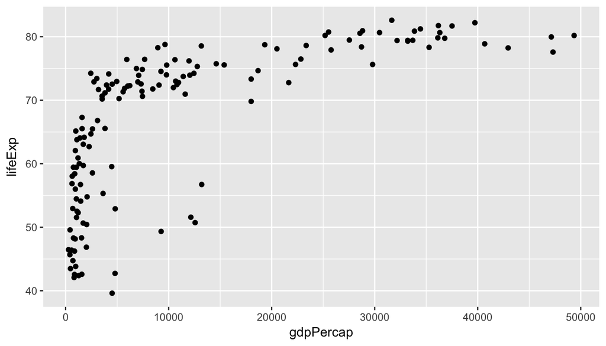

```r
qplot(x = gdpPercap, y = lifeExp, data = gap07)
```

## 第五步: 深入分析1

**任务:** 各个大陆的点使用不同的颜色.

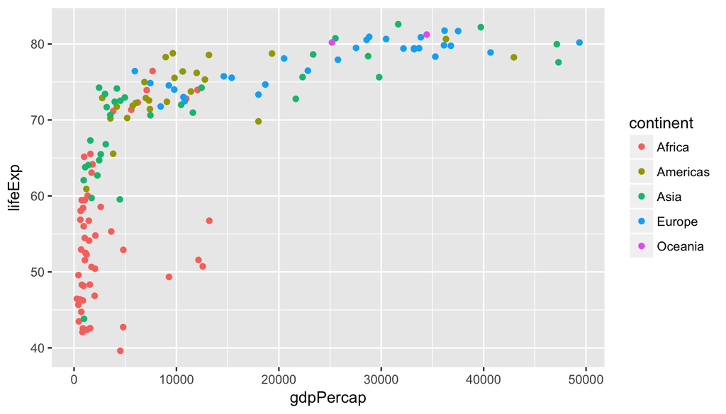

```r
qplot(x = gdpPercap, y = lifeExp, color = continent, data = gap07)
```

## 第五步: 深入分析2

**任务:** 在设定点的大小与人口规模成正比.

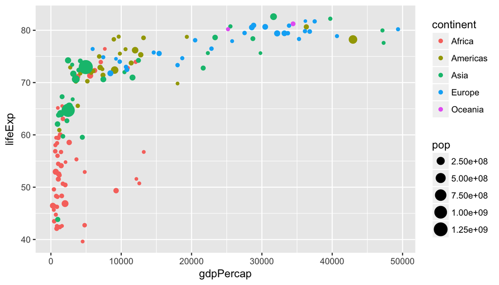

```r
qplot(x = gdpPercap, y = lifeExp, color = continent, size = pop,data = gap07)
```

## 第六步:确认修改并上传

- 选择：Stage
- 确认：Commit (with a message)
- 上传：Push

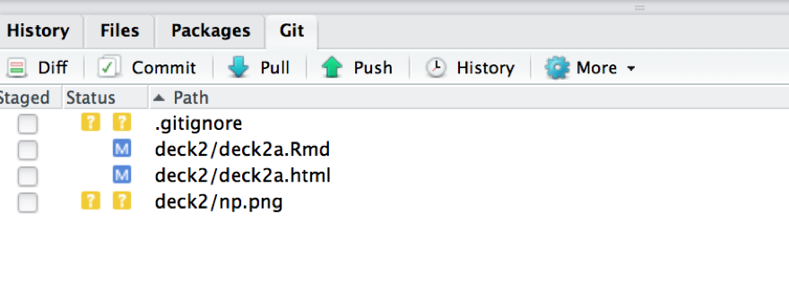

## 自己动手试试？

如果我们选择1952年的数据进行做一些分析呢？

## Homework

阅读tidydata的介绍 http://www.jstatsoft.org/v59/i10/paper